# Reproducible Research PA1

Faisal Sardar

Saturday, May 16, 2015

**Loading and preprocessing the data**

Show any code that is needed to

- Load the data (i.e. read.csv())
- Process/transform the data (if necessary) into a format suitable for your analysis

```r
if(!file.exists("data")){
  dir.create("data")
}

if(!"Activity.zip" %in% dir("./data/")){
  URLFile<-"https://d396qusza40orc.cloudfront.net/repdata%2Fdata%2Factivity.zip"
  download.file(URLFile,destfile="./data/Activity.zip")
  unzip("./data/Activity.zip", files = NULL, list = FALSE, overwrite = TRUE,
        junkpaths = FALSE, exdir = "./data", unzip = "internal",
        setTimes = FALSE)
  dateDownloaded<-date()
} else {print("Already downloaded!")}


AMonitor<-data.table(read.csv("./data/activity.csv"))
head(AMonitor)
str(AMonitor)

#ignoring rows with na
AMonitor<-na.omit(AMonitor)
#set date variable to date class
AMonitor <- AMonitor[, date := as.Date(date)]
setkey(AMonitor, date, interval)
head(AMonitor)
```

[output not shown]

**What is mean total number of steps taken per day?**

For this part of the assignment, you can ignore the missing values in the dataset.

- Calculate the total number of steps taken per day

```r
TotalDailySteps <- AMonitor[, list(DailySteps = sum(steps)), date]
TotalDailySteps
```

```
##           date DailySteps
##  1: 2012-10-02        126
##  2: 2012-10-03      11352
##  3: 2012-10-04      12116
##  4: 2012-10-05      13294
##  5: 2012-10-06      15420
##  6: 2012-10-07      11015
##  7: 2012-10-09      12811
##  8: 2012-10-10       9900
##  9: 2012-10-11      10304
## 10: 2012-10-12      17382
## 11: 2012-10-13      12426
## 12: 2012-10-14      15098
## 13: 2012-10-15      10139
## 14: 2012-10-16      15084
```

[output cut: 40 more lines]

- If you do not understand the difference between a histogram and a barplot, research the difference between them. Make a histogram of the total number of steps taken each day

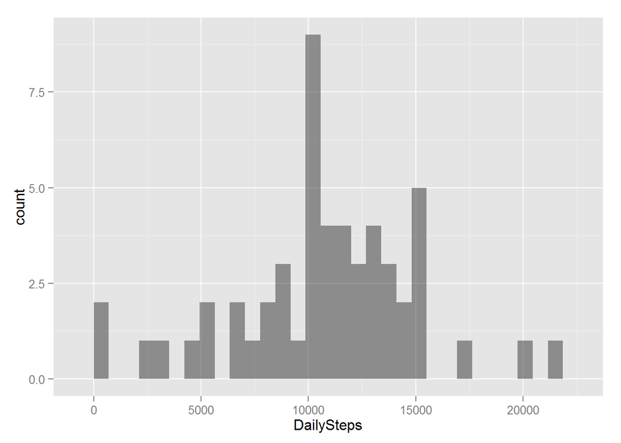

```r
ggplot(TotalDailySteps, aes(x=DailySteps)) +
  geom_histogram(alpha=.5)
```

- Calculate and report the mean and median of the total number of steps taken per day

```r
mean(TotalDailySteps$DailySteps)
```

```
## [1] 10766.19
```

```r
median(TotalDailySteps$DailySteps)
```

```
## [1] 10765
```

**What is the average daily activity pattern?**

- Make a time series plot (i.e. type = “l”) of the 5-minute interval (x-axis) and the average number of steps taken, averaged across all days (y-axis)

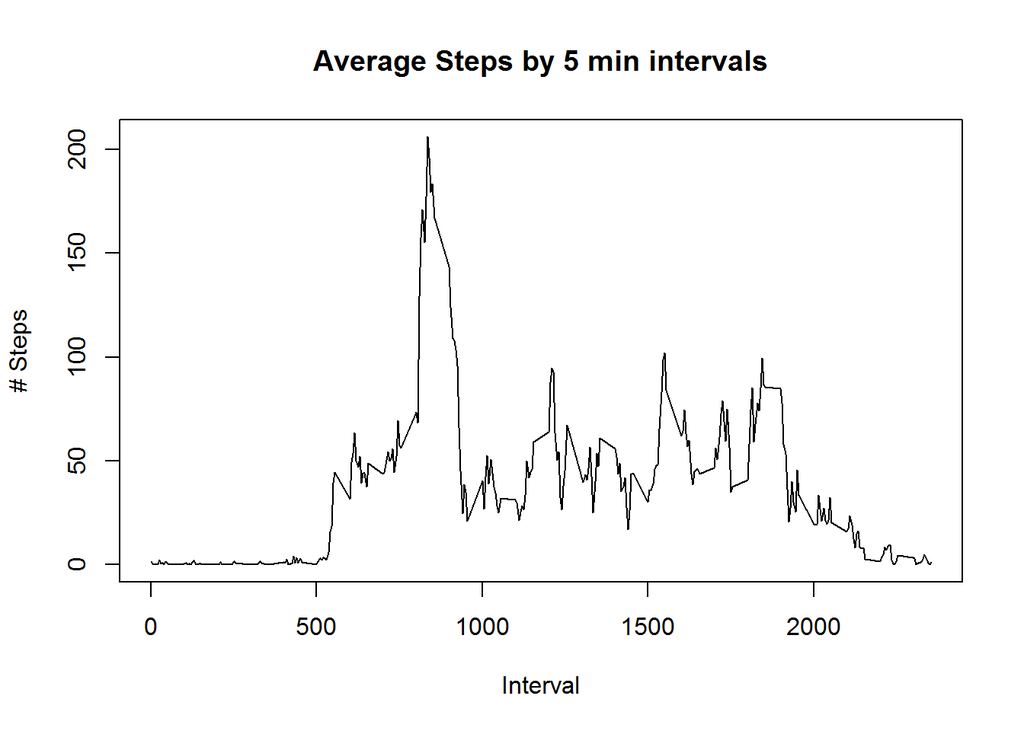

```r
steps_by_interval <- aggregate(steps ~ interval, data=AMonitor, mean)
plot(steps_by_interval$interval,steps_by_interval$steps, type="l",
     xlab="Interval", ylab="# Steps",main="Average Steps by 5 min intervals")
```

- Which 5-minute interval, on average across all the days in the dataset, contains the maximum number of steps?

```r
MeanStepsPerInterval<-ddply(AMonitor, c("interval"),summarise,meansteps = mean(steps))
```

Max Interval:

```r
MeanStepsPerInterval[which(MeanStepsPerInterval$meansteps
                   ==max(MeanStepsPerInterval$meansteps)), "interval"]
```

```
## [1] 835
```

Max Steps:

```r
MeanStepsPerInterval[which(MeanStepsPerInterval$meansteps
                   ==max(MeanStepsPerInterval$meansteps)), "meansteps"]
```

```
## [1] 206.1698
```

**Imputing missing values**

Note that there are a number of days/intervals where there are missing values (coded as NA). The presence of missing days may introduce bias into some calculations or summaries of the data.

- Calculate and report the total number of missing values in the dataset (i.e. the total number of rows with NAs)

```r
MissingValues<-data.table(read.csv("./data/activity.csv"))
CountMV <- sum(!complete.cases(MissingValues))
CountMV
```

```
## [1] 2304
```

**Are there differences in activity patterns between weekdays and weekends?**

- Create a new factor variable in the dataset with two levels – “weekday” and “weekend” indicating whether a given date is a weekday or weekend day.

```r
DOWLevels <- c("Sunday", "Monday", "Tuesday", "Wednesday", "Thursday", "Friday", "Saturday")
WDWELevels <- c("Weekend", "Weekday", "Weekday","Weekday","Weekday","Weekday","Weekday","Weekend")
DOWComp <- AMonitor[, DOW := factor(weekdays(date), levels=DOWLevels)]
DOWComp <- AMonitor[, WDWE := factor(WDWELevels[DOW])]
DOWComp[, .N, list(WDWE, DOW)]
WDWEIntervals <- DOWComp[, list(meanSteps = mean(steps)), list(WDWE, interval)]
```

[output not shown]

[output not shown]

- Make a panel plot containing a time series plot (i.e. type = “l”) of the 5-minute interval (x-axis) and the average number of steps taken, averaged across all weekday days or weekend days (y-axis). The plot should look something like the following, which was creating using simulated data:

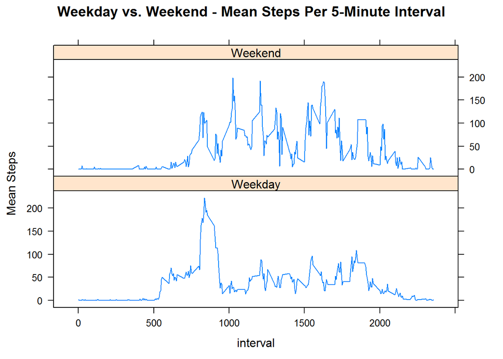

```r
xyplot(meanSteps ~ interval | WDWE,
       data=WDWEIntervals, type="l", layout=c(1,2),
       ylab = "Mean Steps", main="Weekday vs. Weekend - Mean Steps Per 5-Minute Interval")
```